# Slide a computation over signal values

A central tool in the `epiprocess` package is `epi_slide()`, which is based on the powerful functionality provided in the [`slider`](https://cran.r-project.org/web/packages/slider) package. In `epiprocess`, to “slide” means to apply a computation—represented as a function or formula—over a sliding/rolling data window. Suitable groupings can always be achieved by a preliminary call to `group_by()`.

By default, the meaning of one time step is inferred from the `time_value` column of the `epi_df` object under consideration, based on the way this column understands addition and subtraction. For example, if the time values are coded as `Date` objects, then one time step is one day, since `as.Date("2022-01-01") + 1` equals `as.Date("2022-01-02")`. Alternatively, the time step can be specified manually in the call to `epi_slide()`; you can read the documentation for more details. Furthermore, the alignment of the running window used in `epi_slide()` can be “right”, “center”, or “left”; the default is “right”, and is what we use in this vignette.

```r
library(epidatr)
library(epiprocess)
library(dplyr)
```

The data is fetched with the following query:

```r
x <- pub_covidcast(
  source = "jhu-csse",
  signals = "confirmed_incidence_num",
  geo_type = "state",
  time_type = "day",
  geo_values = "ca,fl,ny,tx,ga,pa",
  time_values = epirange(20200301, 20211231),
) %>%
  select(geo_value, time_value, cases = value) %>%
  arrange(geo_value, time_value) %>%
  as_epi_df()
```

## Slide with a formula

We first demonstrate how to apply a 7-day trailing average to the daily cases in order to smooth the signal, by passing in a formula for the first argument of `epi_slide()`. To do this computation per state, we first call `group_by()`.

```r
x %>%
  group_by(geo_value) %>%
  epi_slide(~ mean(.x$cases), before = 6) %>%
  ungroup() %>%
  head(10)
```

```
## An `epi_df` object, 10 x 4 with metadata:
## * geo_type  = state
## * time_type = day
## * as_of     = 2024-01-26 09:27:32.755949
##
## # A tibble: 10 × 4
##    geo_value time_value cases slide_value
##  * <chr>     <date>     <dbl>       <dbl>
##  1 ca        2020-03-01     6        6
##  2 ca        2020-03-02     4        5
##  3 ca        2020-03-03     6        5.33
##  4 ca        2020-03-04    11        6.75
##  5 ca        2020-03-05    10        7.4
##  6 ca        2020-03-06    18        9.17
##  7 ca        2020-03-07    26       11.6
##  8 ca        2020-03-08    19       13.4
##  9 ca        2020-03-09    23       16.1
## 10 ca        2020-03-10    22       18.4
```

The formula specified has access to all non-grouping columns present in the original `epi_df` object (and must refer to them with the prefix `.x$`). As we can see, the function `epi_slide()` returns an `epi_df` object with a new column appended that contains the results (from sliding), named `slide_value` as the default. We can of course change this post hoc, or we can instead specify a new name up front using the `new_col_name` argument:

```r
x <- x %>%
  group_by(geo_value) %>%
  epi_slide(~ mean(.x$cases), before = 6, new_col_name = "cases_7dav") %>%
  ungroup()

head(x, 10)
```

```
## An `epi_df` object, 10 x 4 with metadata:
## * geo_type  = state
## * time_type = day
## * as_of     = 2024-01-26 09:27:32.755949
##
## # A tibble: 10 × 4
##    geo_value time_value cases cases_7dav
##  * <chr>     <date>     <dbl>      <dbl>
##  1 ca        2020-03-01     6       6
##  2 ca        2020-03-02     4       5
##  3 ca        2020-03-03     6       5.33
##  4 ca        2020-03-04    11       6.75
##  5 ca        2020-03-05    10       7.4
##  6 ca        2020-03-06    18       9.17
##  7 ca        2020-03-07    26      11.6
##  8 ca        2020-03-08    19      13.4
##  9 ca        2020-03-09    23      16.1
## 10 ca        2020-03-10    22      18.4
```

Some other information is available in additional variables:

- `.group_key` is a one-row tibble containing the values of the grouping variables for the associated group
- `.ref_time_value` is the reference time value the time window was based on

Like in `group_modify()`, there are alternative names for these variables as well: `.` can be used instead of `.x`, `.y` instead of `.group_key`, and `.z` instead of `.ref_time_value`.

## Slide with a function

We can also pass a function for the first argument in `epi_slide()`. In this case, the passed function must accept the following arguments:

In this case, the passed function `f` must accept the following arguments: a data frame with the same column names as the original object, minus any grouping variables, containing the time window data for one group-`ref_time_value` combination; followed by a one-row tibble containing the values of the grouping variables for the associated group; followed by the associated `ref_time_value`. It can accept additional arguments; `epi_slide()` will forward any `...` args it receives to `f`.

Recreating the last example of a 7-day trailing average:

```r
x <- x %>%
  group_by(geo_value) %>%
  epi_slide(function(x, gk, rtv) mean(x$cases), before = 6, new_col_name = "cases_7dav") %>%
  ungroup()

head(x, 10)
```

```
## An `epi_df` object, 10 x 4 with metadata:
## * geo_type  = state
## * time_type = day
## * as_of     = 2024-01-26 09:27:32.755949
##
## # A tibble: 10 × 4
##    geo_value time_value cases cases_7dav
##  * <chr>     <date>     <dbl>      <dbl>
##  1 ca        2020-03-01     6       6
##  2 ca        2020-03-02     4       5
##  3 ca        2020-03-03     6       5.33
##  4 ca        2020-03-04    11       6.75
##  5 ca        2020-03-05    10       7.4
##  6 ca        2020-03-06    18       9.17
##  7 ca        2020-03-07    26      11.6
##  8 ca        2020-03-08    19      13.4
##  9 ca        2020-03-09    23      16.1
## 10 ca        2020-03-10    22      18.4
```

## Slide the tidy way

Perhaps the most convenient way to setup a computation in `epi_slide()` is to pass in an expression for tidy evaluation. In this case, we can simply define the name of the new column directly as part of the expression, setting it equal to a computation in which we can access any columns of `x` by name, just as we would in a call to `dplyr::mutate()`, or any of the `dplyr` verbs. For example:

```r
x <- x %>%
  group_by(geo_value) %>%
  epi_slide(cases_7dav = mean(cases), before = 6) %>%
  ungroup()

head(x, 10)
```

```
## An `epi_df` object, 10 x 4 with metadata:
## * geo_type  = state
## * time_type = day
## * as_of     = 2024-01-26 09:27:32.755949
##
## # A tibble: 10 × 4
##    geo_value time_value cases cases_7dav
##  * <chr>     <date>     <dbl>      <dbl>
##  1 ca        2020-03-01     6       6
##  2 ca        2020-03-02     4       5
##  3 ca        2020-03-03     6       5.33
##  4 ca        2020-03-04    11       6.75
##  5 ca        2020-03-05    10       7.4
##  6 ca        2020-03-06    18       9.17
##  7 ca        2020-03-07    26      11.6
##  8 ca        2020-03-08    19      13.4
##  9 ca        2020-03-09    23      16.1
## 10 ca        2020-03-10    22      18.4
```

In addition to referring to individual columns by name, you can refer to the time window data as an `epi_df` or `tibble` using `.x`. Similarly, the other arguments of the function format are available through the magic names `.group_key` and `.ref_time_value`, and the tidyverse “pronouns” `.data` and `.env` can also be used.

As a simple sanity check, we visualize the 7-day trailing averages computed on top of the original counts:

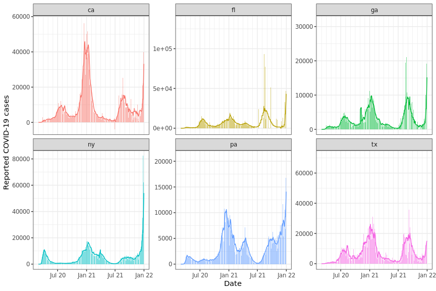

```r
library(ggplot2)
theme_set(theme_bw())

ggplot(x, aes(x = time_value)) +
  geom_col(aes(y = cases, fill = geo_value), alpha = 0.5, show.legend = FALSE) +
  geom_line(aes(y = cases_7dav, col = geo_value), show.legend = FALSE) +
  facet_wrap(~geo_value, scales = "free_y") +
  scale_x_date(minor_breaks = "month", date_labels = "%b %y") +
  labs(x = "Date", y = "Reported COVID-19 cases")
```

## Running a local forecaster

As a more complex example, we create a forecaster based on a local (in time) autoregression or AR model. AR models can be fit in numerous ways (using base R functions and various packages), but here we define it “by hand” both because it provides a more advanced example of sliding a function over an `epi_df` object, and because it allows us to be a bit more flexible in defining a *probabilistic* forecaster: one that outputs not just a point prediction, but a notion of uncertainty around this. In particular, our forecaster will output a point prediction along with an 90% uncertainty band, represented by a predictive quantiles at the 5% and 95% levels (lower and upper endpoints of the uncertainty band).

The function defined below, `prob_ar()`, is our probabilistic AR forecaster. The `lags`argument indicates which lags to use in the model, and `ahead` indicates how far ahead in the future to make forecasts (both are encoded in terms of the units of the `time_value` column; so, days, in the working `epi_df` being considered in this vignette).

```r
prob_ar <- function(y, lags = c(0, 7, 14), ahead = 6, min_train_window = 20,
                    lower_level = 0.05, upper_level = 0.95, symmetrize = TRUE,
                    intercept = FALSE, nonneg = TRUE) {
  # Return NA if insufficient training data
  if (length(y) < min_train_window + max(lags) + ahead) {
    return(data.frame(point = NA, lower = NA, upper = NA))
  }

  # Build features and response for the AR model
  dat <- do.call(
    data.frame,
    purrr::map(lags, function(j) lag(y, n = j))
  )
  names(dat) <- paste0("x", seq_len(ncol(dat)))
  if (intercept) dat$x0 <- rep(1, nrow(dat))
  dat$y <- lead(y, n = ahead)

  # Now fit the AR model and make a prediction
  obj <- lm(y ~ . + 0, data = dat)
  point <- predict(obj, newdata = tail(dat, 1))

  # Compute a band
  r <- residuals(obj)
  s <- ifelse(symmetrize, -1, NA) # Should the residuals be symmetrized?
  q <- quantile(c(r, s * r), probs = c(lower_level, upper_level), na.rm = TRUE)
  lower <- point + q[1]
  upper <- point + q[2]

  # Clip at zero if we need to, then return
  if (nonneg) {
    point <- max(point, 0)
    lower <- max(lower, 0)
    upper <- max(upper, 0)
  }
  return(data.frame(point = point, lower = lower, upper = upper))
}
```

We go ahead and slide this AR forecaster over the working `epi_df` of COVID-19 cases. Note that we actually model the `cases_7dav` column, to operate on the scale of smoothed COVID-19 cases. This is clearly equivalent, up to a constant, to modeling weekly sums of COVID-19 cases.

```r
fc_time_values <- seq(as.Date("2020-06-01"),
  as.Date("2021-12-01"),
  by = "1 months"
)
x %>%
  group_by(geo_value) %>%
  epi_slide(
    fc = prob_ar(cases_7dav), before = 119,
    ref_time_values = fc_time_values
  ) %>%
  ungroup() %>%
  head(10)
```

```
## An `epi_df` object, 10 x 7 with metadata:
## * geo_type  = state
## * time_type = day
## * as_of     = 2024-01-26 09:27:32.755949
##
## # A tibble: 10 × 7
##    geo_value time_value cases cases_7dav fc_point fc_lower fc_upper
##  * <chr>     <date>     <dbl>      <dbl>    <dbl>    <dbl>    <dbl>
##  1 ca        2020-06-01  2437      2694     2973.    2566.    3380.
##  2 ca        2020-07-01  7346      6722     7892.    7321.    8462.
##  3 ca        2020-08-01  8616      8284.    7188.    6153.    8223.
##  4 ca        2020-09-01  4248      4707.    4133.    2329.    5937.
##  5 ca        2020-10-01  3504      3360.    3257.    1449.    5064.
##  6 ca        2020-11-01  4210      4441.    3840.    2258.    5422.
##  7 ca        2020-12-01 23626     15690    17699.   16082.   19316.
##  8 ca        2021-01-01 50251     41097.   45534.   38417.   52650.
##  9 ca        2021-02-01 13098     17952.   15266.    6725.   23808.
## 10 ca        2021-03-01  3031      5209     4482.       0    12982.
```

To finish off, we plot the forecasts at some times (spaced out by a few months) over the last year, at multiple horizons: 7, 14, 21, and 28 days ahead. To do so, we encapsulate the process of generating forecasts into a simple function, so that we can call it a few times.

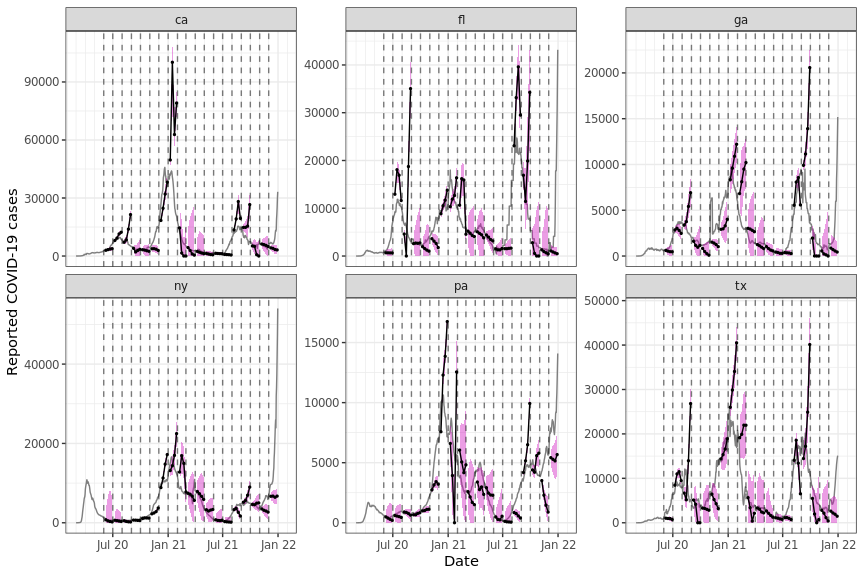

```r
# Note the use of all_rows = TRUE (keeps all original rows in the output)
k_week_ahead <- function(x, ahead = 7) {
  x %>%
    group_by(.data$geo_value) %>%
    epi_slide(
      fc = prob_ar(.data$cases_7dav, ahead = ahead), before = 119,
      ref_time_values = fc_time_values, all_rows = TRUE
    ) %>%
    ungroup() %>%
    mutate(target_date = .data$time_value + ahead)
}

# First generate the forecasts, and bind them together
z <- bind_rows(
  k_week_ahead(x, ahead = 7),
  k_week_ahead(x, ahead = 14),
  k_week_ahead(x, ahead = 21),
  k_week_ahead(x, ahead = 28)
)

# Now plot them, on top of actual COVID-19 case counts
ggplot(z) +
  geom_line(aes(x = time_value, y = cases_7dav), color = "gray50") +
  geom_ribbon(aes(
    x = target_date, ymin = fc_lower, ymax = fc_upper,
    group = time_value
  ), fill = 6, alpha = 0.4) +
  geom_line(aes(x = target_date, y = fc_point, group = time_value)) +
  geom_point(aes(x = target_date, y = fc_point, group = time_value),
    size = 0.5
  ) +
  geom_vline(
    data = tibble(x = fc_time_values), aes(xintercept = x),
    linetype = 2, alpha = 0.5
  ) +
  facet_wrap(vars(geo_value), scales = "free_y") +
  scale_x_date(minor_breaks = "month", date_labels = "%b %y") +
  labs(x = "Date", y = "Reported COVID-19 cases")
```

Two points are worth making. First, the AR model’s performance here is pretty spotty. At various points in time, we can see that its forecasts are volatile (its point predictions are all over the place), or overconfident (its bands are too narrow), or both at the same time. This is only meant as a simple demo and not entirely unexpected given the way the AR model is set up. The [`epipredict`](https://cmu-delphi.github.io/epipredict) package, which is a companion package to `epiprocess`, offers a suite of predictive modeling tools that can improve on some of the shortcomings of the above simple AR model.

Second, the AR forecaster here is using finalized data, meaning, it uses the latest versions of signal values (reported COVID-19 cases) available, for both training models and making predictions historically. However, this is not reflective of the provisional nature of the data that it must cope with in a true forecast task. Training and making predictions on finalized data can lead to an overly optimistic sense of accuracy; see, for example, [McDonald et al. (2021)](https://www.pnas.org/content/118/51/e2111453118/), and references therein. Fortunately, the `epiprocess` package provides a data structure called `epi_archive` that can be used to store all data revisions, and furthermore, an `epi_archive` object knows how to slide computations in the correct version-aware sense (for the computation at each reference time $t$, it uses only data that would have been available as of $t$). We will revisit this example in the [archive vignette](https://cmu-delphi.github.io/epiprocess/articles/archive.html).

## Attribution

This document contains a dataset that is a modified part of the [COVID-19 Data Repository by the Center for Systems Science and Engineering (CSSE) at Johns Hopkins University](https://github.com/CSSEGISandData/COVID-19) as [republished in the COVIDcast Epidata API](https://cmu-delphi.github.io/delphi-epidata/api/covidcast-signals/jhu-csse.html). This data set is licensed under the terms of the [Creative Commons Attribution 4.0 International license](https://creativecommons.org/licenses/by/4.0/) by the Johns Hopkins University on behalf of its Center for Systems Science in Engineering. Copyright Johns Hopkins University 2020.

[From the COVIDcast Epidata API](https://cmu-delphi.github.io/delphi-epidata/api/covidcast-signals/jhu-csse.html): These signals are taken directly from the JHU CSSE [COVID-19 GitHub repository](https://github.com/CSSEGISandData/COVID-19) without changes.